# Intención de voto elecciones presidenciales Colombia 2022

Exploración estadística

Edimer David Jaramillo

2022-03-12

# Bibliotecas

```r
library(tidyverse)
library(readxl)
library(janitor)
library(DT)
library(rvest)
library(lubridate)
library(cowplot)
library(ggsci)
library(splines)
library(qqplotr)
```

# Consultas presidenciales

## Candidatos

[figure not shown]

## Datos

- En total hay 62 encuestas.

```r
datos <- read_csv("EncuestasWikipedia-Colombia2022.csv") %>%
  mutate(fecha_publicacion = as.Date(fecha_publicacion, format = "%d-%m-%Y")) %>%
  select(fuente:margen_de_error,
         alfredo_saade,
         arelis_uriana,
         camilo_romero,
         francia_marquez,
         gustavo_petro,

         alejandro_gaviria,
         carlos_amaya,
         jorge_enrique_robledo,
         juan_manuel_galan,
         sergio_fajardo,

         alejandro_char,
         aydee_lizarazo,
         david_barguil,
         enrique_penalosa,
         federico_gutierrez,

         blanco,
         ninguno,
         ns_nr
         )
datos
```

| fuente | firma_encuestadora | fecha_publicacion | muestra | margen_de_error | alfredo_saade | arelis_uriana | camilo_romero | francia_marquez | gustavo_petro | alejandro_gaviria | carlos_amaya | jorge_enrique_robledo | juan_manuel_galan | sergio_fajardo | alejandro_char | aydee_lizarazo | david_barguil | enrique_penalosa | federico_gutierrez | blanco | ninguno | ns_nr |
| --- | --- | --- | --- | --- | --- | --- | --- | --- | --- | --- | --- | --- | --- | --- | --- | --- | --- | --- | --- | --- | --- | --- |
| El Tiempo[1] | Guarumo | 2022-03-06 | 2345 | 2.50 | 0.2 | 1.8 | 5.9 | 10.5 | 81.6 | NA | NA | NA | NA | NA | NA | NA | NA | NA | NA | NA | NA | NA |
| BluRadio[2] | Invamer | 2022-03-04 | 1504 | 2.92 | 0.3 | 1.7 | 5.9 | 13.5 | 78.6 | NA | NA | NA | NA | NA | NA | NA | NA | NA | NA | NA | NA | NA |
| El Tiempo[3] | CNC | 2022-02-05 | 2206 | 2.10 | 1.0 | 4.0 | 4.0 | 12.0 | 77.0 | NA | NA | NA | NA | NA | NA | NA | NA | NA | NA | NA | 1.0 | 0.6 |
| Semana[4] | CNC | 2021-12-11 | 4093 | 1.50 | NA | 1.0 | 4.0 | 3.0 | 89.0 | NA | NA | NA | NA | NA | NA | NA | NA | NA | NA | NA | 1.0 | 1.0 |
| Caracol TV[5] | Invamer | 2021-12-05 | 1200 | 3.49 | 0.0 | 2.8 | 4.5 | 7.5 | 82.4 | NA | NA | NA | NA | NA | NA | NA | NA | NA | NA | 0.0 | NA | NA |
| El Tiempo[1] | Guarumo | 2022-03-06 | 2345 | 2.50 | NA | NA | NA | NA | NA | 21.5 | 10.4 | 8.5 | 22.1 | 37.5 | NA | NA | NA | NA | NA | NA | NA | NA |
| BluRadio[2] | Invamer | 2022-03-04 | 1504 | 2.92 | NA | NA | NA | NA | NA | 12.9 | 14.9 | 10.5 | 23.9 | 37.8 | NA | NA | NA | NA | NA | NA | NA | NA |
| El Tiempo[3] | CNC | 2022-02-05 | 2206 | 2.10 | NA | NA | NA | NA | NA | 11.0 | 8.0 | 5.0 | 31.0 | 39.0 | NA | NA | NA | NA | NA | NA | 4.0 | 1.0 |
| Semana[4] | CNC | 2021-12-11 | 4093 | 1.50 | NA | NA | NA | NA | NA | 17.0 | 4.0 | 3.0 | 31.0 | 43.0 | NA | NA | NA | NA | NA | NA | 2.0 | 2.0 |
| Caracol TV[5] | Invamer | 2021-12-05 | 1200 | 3.49 | NA | NA | NA | NA | NA | 9.5 | 5.3 | 5.5 | 32.4 | 43.5 | NA | NA | NA | NA | NA | 0.7 | NA | NA |

[output cut: 52 more lines]

## Firmas encuestadoras

- El siguiente gráfico muestra el total de encuestas realizadas por cada firma encuestadora (**A**) y el total de encuestas realizadas por cada firma encuestadora por año (**B**).

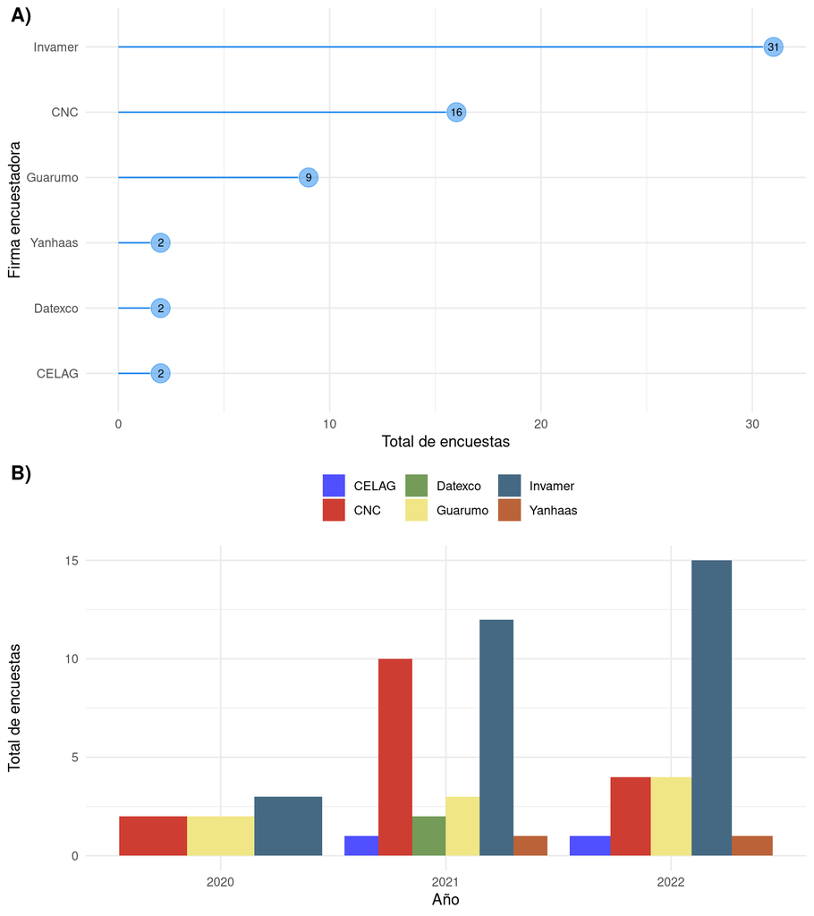

```r
g1 <-
  datos %>%
  count(firma_encuestadora) %>%
  ggplot(aes(x = fct_reorder(firma_encuestadora, n), y = n)) +
  geom_segment(aes(
    x = fct_reorder(firma_encuestadora, n),
    xend = fct_reorder(firma_encuestadora, n),
    y = 0,
    yend = n - 0.5
  ),
  color = "dodgerblue2") +
  geom_point(size = 6,
             alpha = 0.5,
             color = "dodgerblue2") +
  geom_text(aes(label = n), size = 2.7) +
  coord_flip() +
  labs(x = "Firma encuestadora",
       y = "Total de encuestas")

g2 <-
  datos %>%
  mutate(year = year(fecha_publicacion)) %>%
  count(firma_encuestadora, year) %>%
  filter(!is.na(year)) %>%
  mutate(year = as.factor(year)) %>%
  ggplot(aes(x = year, y = n, fill = firma_encuestadora)) +
  geom_col(position = "dodge") +
  scale_fill_igv() +
  labs(x = "Año",
       y = "Total de encuestas",
       fill = "",
       color = "") +
  theme(legend.position = "top")

plot_grid(g1,
          g2,
          ncol = 1,
          align = "hv",
          labels = list("A)", "B)"))
```

## Encuestas por candidato y coalición

- En el gráfico **A** se muestra el total de encuestas en las que ha sido evaluada la intención de voto para cada candidato. En el gráfico **B** se observa el total de encuestas en las que se ha medido la intención de voto para cada coalición en cada año.

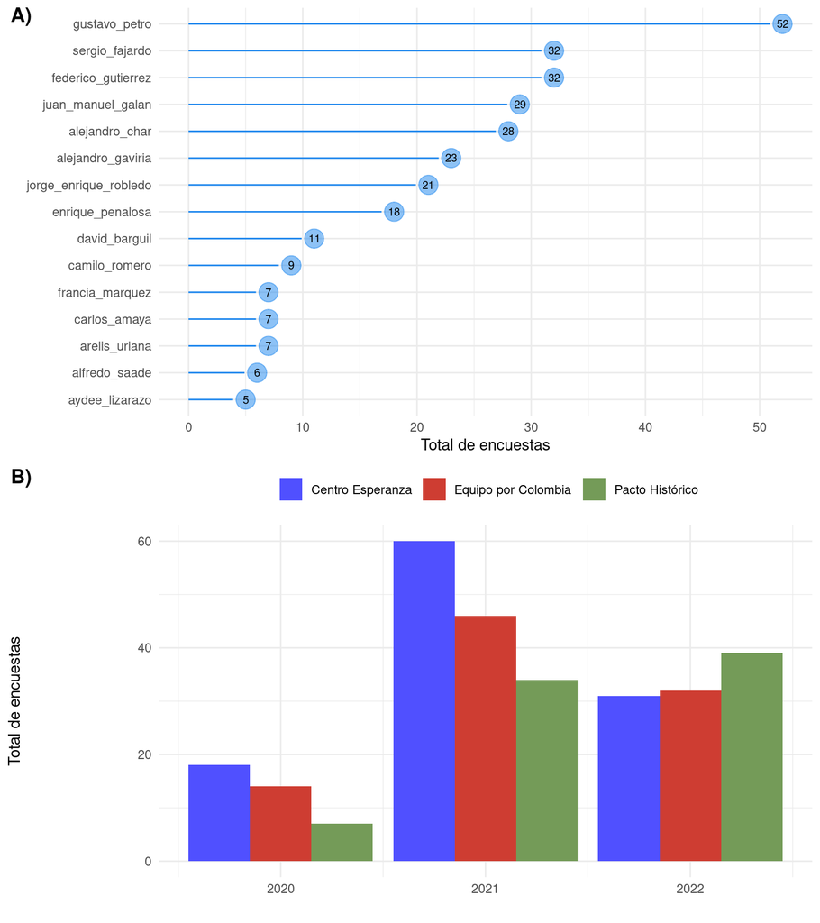

```r
g1 <- datos %>%
  select(alfredo_saade:federico_gutierrez) %>%
  pivot_longer(cols = everything()) %>%
  group_by(name) %>%
  summarise(total_encuestas = sum(!is.na(value))) %>%
  ungroup() %>%
  ggplot(aes(x = fct_reorder(name, total_encuestas), y = total_encuestas)) +
  geom_segment(aes(
    x = fct_reorder(name, total_encuestas),
    xend = fct_reorder(name, total_encuestas),
    y = 0,
    yend = total_encuestas - 1.1
  ),
  color = "dodgerblue2") +
  geom_point(size = 6,
             alpha = 0.5,
             color = "dodgerblue2") +
  geom_text(aes(label = total_encuestas), size = 2.7) +
  coord_flip() +
  labs(x = "",
       y = "Total de encuestas")

g2 <- datos %>%
  mutate(year = year(fecha_publicacion)) %>%
  select(alfredo_saade:federico_gutierrez, year) %>%
  pivot_longer(cols = -year) %>%
  mutate(coalicion = if_else(
    name %in% c(
      "alfredo_saade",
      "arelis_uriana",
      "camilo_romero",
      "francia_marquez",
      "gustavo_petro"
    ),
    true = "Pacto Histórico",
    false = if_else(
      name %in% c(
        "alejandro_gaviria",
        "carlos_amaya",
        "jorge_enrique_robledo",
        "juan_manuel_galan",
        "sergio_fajardo"
      ),
      true = "Centro Esperanza",
      false = "Equipo por Colombia"
    )
  )) %>%
  group_by(coalicion, year) %>%
  summarise(total_encuestas = sum(!is.na(value))) %>%
  ungroup() %>%
  filter(!is.na(year)) %>%
  ggplot(aes(
    x = year,
    y = total_encuestas,
    fill = coalicion
  )) +
  geom_col(position = "dodge") +
  scale_fill_igv() +
  scale_color_igv() +
  labs(x = "",
       y = "Total de encuestas",
       fill = "",
       color = "") +
  theme(legend.position = "top")

plot_grid(g1,
          g2,
          ncol = 1,
          align = "hv",
          labels = list("A)", "B)"))
```

## Intención de voto

### Variabilidad temporal

- **Gráfico A:** distribución de la intención de voto de cada coalición para cada año.
- **Gráfico B:** tendencia de la **mediana** de la intención de voto para cada coalición.
- **Gráfico C:** tendencia suavizada ([*modelo GAM*](https://en.wikipedia.org/wiki/Generalized_additive_model)) de la **mediana** de intención de voto para cada coalición.
- **Gráfico D:** tendencia de la **mediana** de la intención de voto para los tres candidatos que lideran (según resultados de encuesta) cada coalición.
- **Nota:** algunos candidatos aparecen recientemente por su tardía vinculación a la precandidatura presidencial.

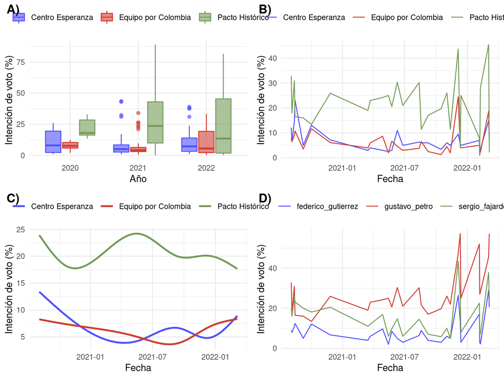

```r
g1 <-
  datos %>%
  mutate(year = year(fecha_publicacion)) %>%
  select(alfredo_saade:federico_gutierrez, year) %>%
  pivot_longer(cols = -year) %>%
  mutate(coalicion = if_else(
    name %in% c(
      "alfredo_saade",
      "arelis_uriana",
      "camilo_romero",
      "francia_marquez",
      "gustavo_petro"
    ),
    true = "Pacto Histórico",
    false = if_else(
      name %in% c(
        "alejandro_gaviria",
        "carlos_amaya",
        "jorge_enrique_robledo",
        "juan_manuel_galan",
        "sergio_fajardo"
      ),
      true = "Centro Esperanza",
      false = "Equipo por Colombia"
    )
  )) %>%
  filter(!is.na(year)) %>%
  mutate(year = as.factor(year)) %>%
  ggplot(aes(
    x = year,
    y = value,
    fill = coalicion,
    color = coalicion
  )) +
  geom_boxplot(alpha = 0.6) +
  scale_fill_igv() +
  scale_color_igv() +
  labs(x = "Año",
       y = "Intención de voto (%)",
       fill = "",
       color = "") +
  theme(legend.position = "top")

g2 <-
  datos %>%
  select(alfredo_saade:federico_gutierrez, fecha_publicacion) %>%
  pivot_longer(cols = -fecha_publicacion) %>%
  mutate(coalicion = if_else(
    name %in% c(
      "alfredo_saade",
      "arelis_uriana",
      "camilo_romero",
      "francia_marquez",
      "gustavo_petro"
    ),
    true = "Pacto Histórico",
    false = if_else(
      name %in% c(
        "alejandro_gaviria",
        "carlos_amaya",
        "jorge_enrique_robledo",
        "juan_manuel_galan",
        "sergio_fajardo"
      ),
      true = "Centro Esperanza",
      false = "Equipo por Colombia"
    )
  )) %>%
  group_by(fecha_publicacion, coalicion) %>%
  summarise(mediana = median(value, na.rm = TRUE)) %>%
  ungroup() %>%
  ggplot(aes(x = fecha_publicacion, y = mediana, color = coalicion)) +
  geom_line() +
  scale_color_igv() +
  labs(x = "Fecha", y = "Intención de voto (%)",
       color = "") +
  theme(legend.position = "top")

g3 <-
  datos %>%
  select(alfredo_saade:federico_gutierrez, fecha_publicacion) %>%
  pivot_longer(cols = -fecha_publicacion) %>%
  mutate(coalicion = if_else(
    name %in% c(
      "alfredo_saade",
      "arelis_uriana",
      "camilo_romero",
      "francia_marquez",
      "gustavo_petro"
    ),
    true = "Pacto Histórico",
    false = if_else(
      name %in% c(
        "alejandro_gaviria",
        "carlos_amaya",
        "jorge_enrique_robledo",
        "juan_manuel_galan",
        "sergio_fajardo"
      ),
      true = "Centro Esperanza",
      false = "Equipo por Colombia"
    )
  )) %>%
  group_by(fecha_publicacion, coalicion) %>%
  summarise(mediana = median(value, na.rm = TRUE)) %>%
  ungroup() %>%
  ggplot(aes(x = fecha_publicacion, y = mediana, color = coalicion)) +
  geom_smooth(method = "gam",
              formula = y ~ ns(x, df = 5),
              se = FALSE) +
  scale_color_igv() +
  labs(x = "Fecha", y = "Intención de voto (%)",
       color = "") +
  theme(legend.position = "top")

g4 <-
  datos %>%
  select(alfredo_saade:federico_gutierrez, fecha_publicacion) %>%
  pivot_longer(cols = -fecha_publicacion) %>%
  group_by(fecha_publicacion, name) %>%
  summarise(mediana = median(value, na.rm = TRUE)) %>%
  ungroup() %>%
  filter(name %in% c("gustavo_petro", "sergio_fajardo", "federico_gutierrez")) %>%
  ggplot(aes(x = fecha_publicacion, y = mediana, color = name)) +
  geom_line() +
  scale_color_igv() +
  labs(x = "Fecha", y = "Intención de voto (%)",
       color = "") +
  theme(legend.position = "top")

plot_grid(g1,
          g2,
          g3,
          g4,
          ncol = 2,
          nrow = 2,
          align = "hv",
          labels = list("A)", "B)", "C)", "D)"))
```

### Exploratorio por candidato

- **Gráfico A:** distribución de la intención de voto del candidato.
- **Gráfico B:** tendencia suavizada ([*modelo GAM*](https://en.wikipedia.org/wiki/Generalized_additive_model)) de la intención de voto a través del tiempo.
- **Gráfico C:** promedio y desviación estándar de la intención de voto por año.
- **Gráfico D:** ranking de promedio de intención de voto.

```r
# Busque esta función en Github (en el inicio está el hipervínculo)
source("explor_candidate.R")
```

#### Gustavo Petro

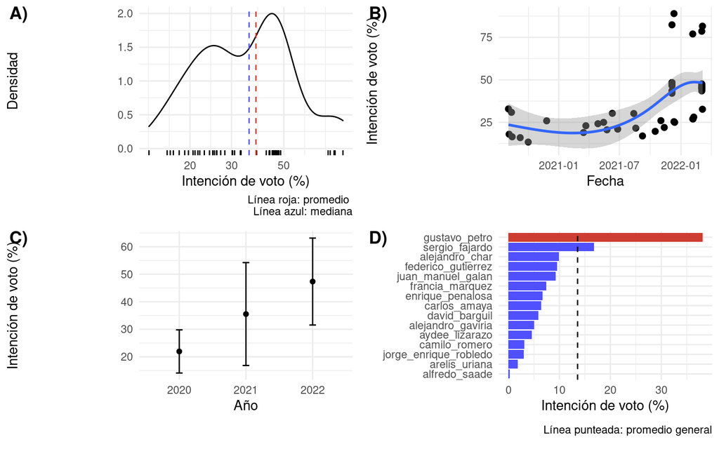

```r
explor_candidate(data = datos, candidate = "gustavo_petro")
```

#### Sergio Fajardo

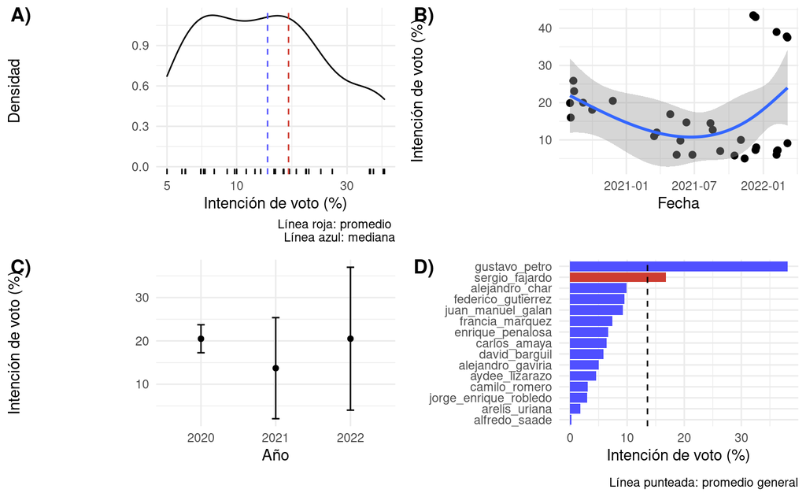

```r
explor_candidate(data = datos, candidate = "sergio_fajardo")
```

#### Alejandro Char

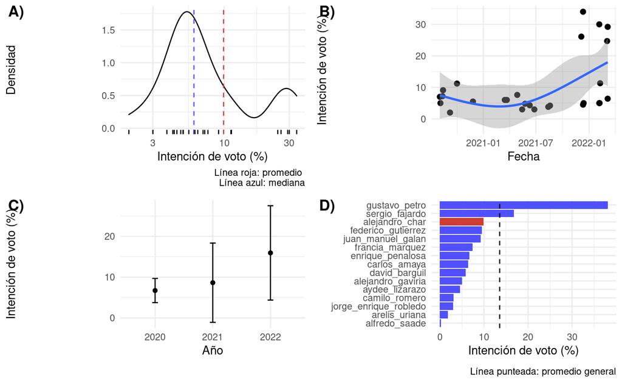

```r
explor_candidate(data = datos, candidate = "alejandro_char")
```

#### Federico Gutiérrez

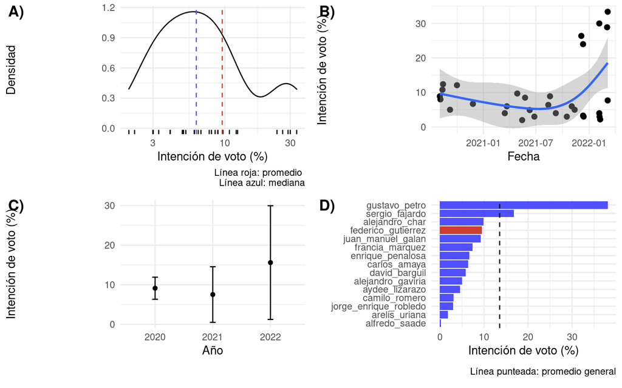

```r
explor_candidate(data = datos, candidate = "federico_gutierrez")
```

#### Juan Manuel Galán

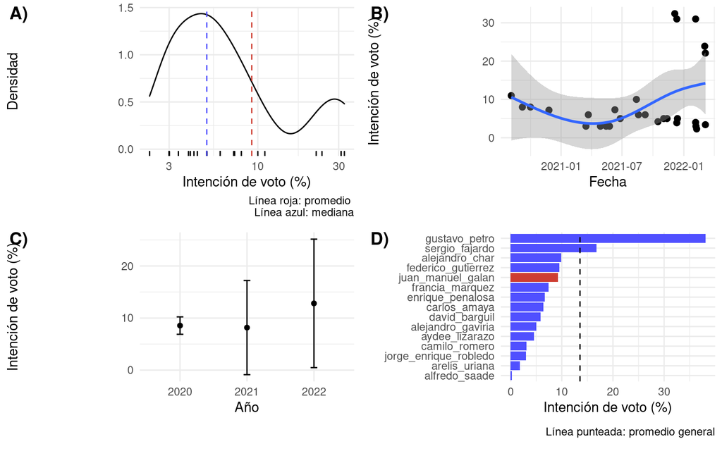

```r
explor_candidate(data = datos, candidate = "juan_manuel_galan")
```

### ¿Normalidad?

#### Escala original

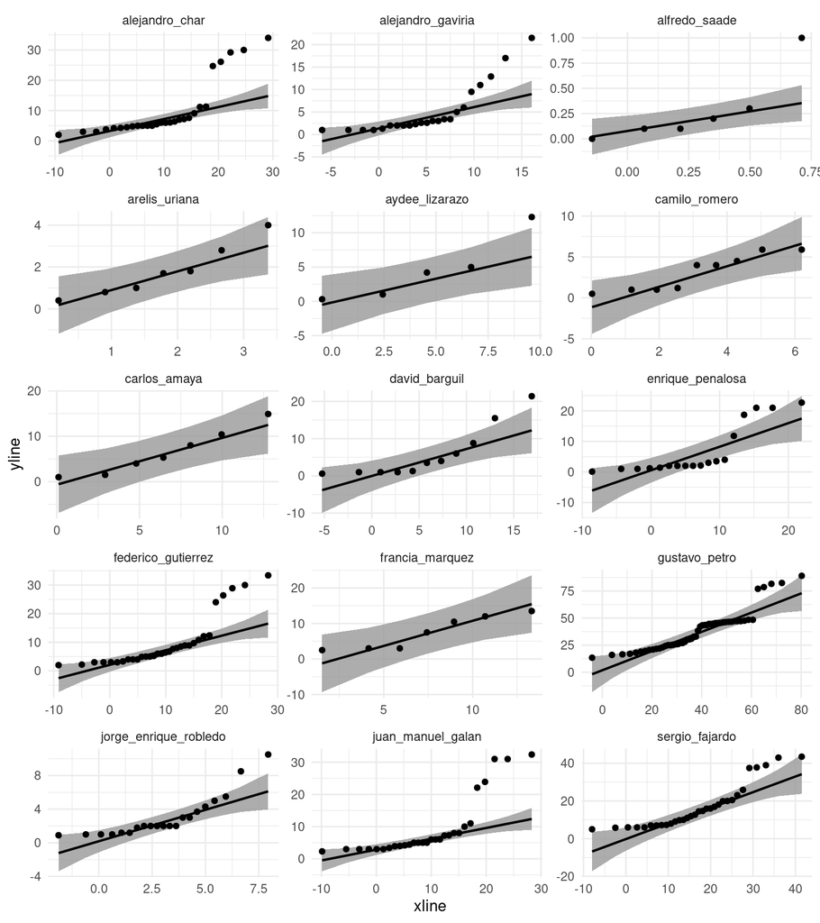

```r
datos %>%
  select(alfredo_saade:federico_gutierrez) %>%
  pivot_longer(cols = everything()) %>%
  ggplot(aes(sample = value)) +
  facet_wrap(~name, scales = "free", ncol = 3, nrow = 5) +
  stat_qq_band() +
  stat_qq_point() +
  stat_qq_line()
```

#### Escala logarítmica

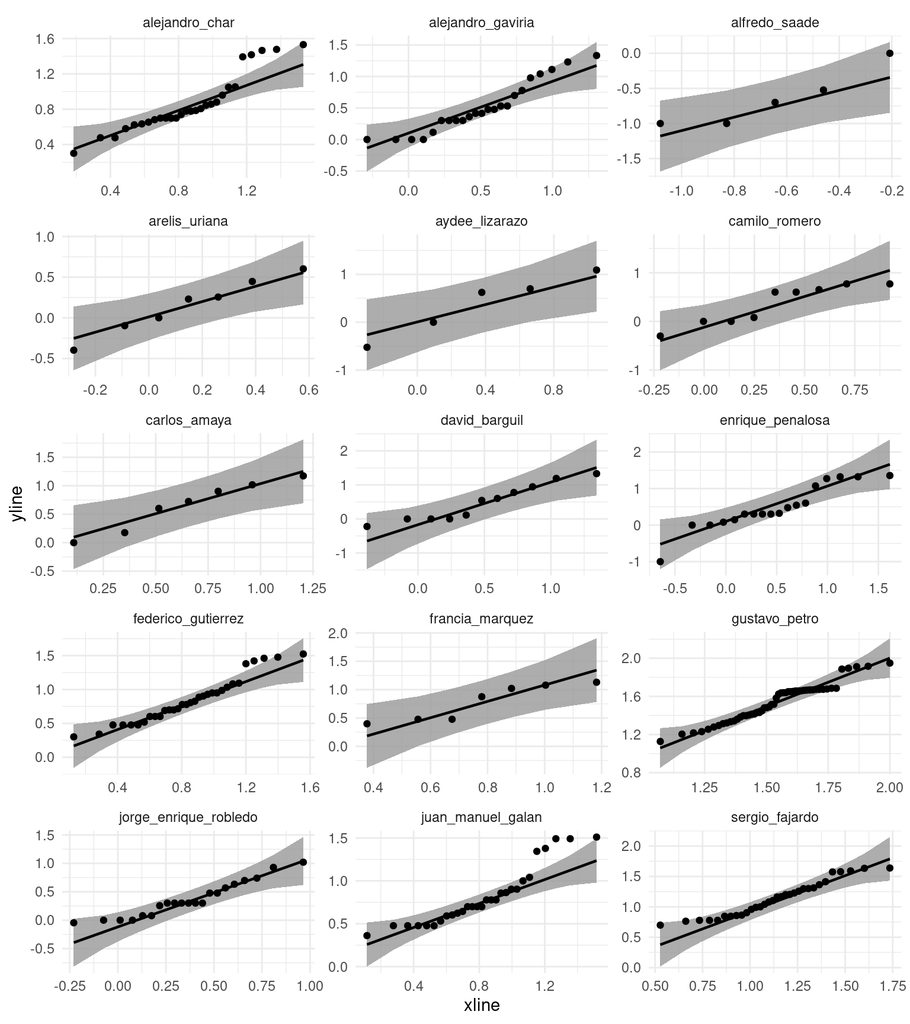

```r
datos %>%
  select(alfredo_saade:federico_gutierrez) %>%
  pivot_longer(cols = everything()) %>%
  mutate(value = log10(value)) %>%
  ggplot(aes(sample = value)) +
  facet_wrap(~name, scales = "free", ncol = 3, nrow = 5) +
  stat_qq_band() +
  stat_qq_point() +
  stat_qq_line()
```

### Estimación 1

- En este caso voy a asumir que cada encuesta es una *realización o experimento*, el parámetro de interés es $\mu_p$, que podría ser descrito como el promedio de intención de voto, esta proporción es de interés estimarla para saber cuál sería el verdadero porcentaje de personas que votaría por un candidato.